# Reproducible Research: Peer Assessment 1

## Part 1

Loading the preprocessing the data

```r
origin_data <- read.csv('activity.csv')
str(origin_data)
```

```
## 'data.frame':    17568 obs. of  3 variables:
##  $ steps   : int  NA NA NA NA NA NA NA NA NA NA ...
##  $ date    : Factor w/ 61 levels "2012-10-01","2012-10-02",..: 1 1 1 1 1 1 1 1 1 1 ...
##  $ interval: int  0 5 10 15 20 25 30 35 40 45 ...
```

```r
data <- na.omit(origin_data)
str(data)
```

```
## 'data.frame':    15264 obs. of  3 variables:
##  $ steps   : int  0 0 0 0 0 0 0 0 0 0 ...
##  $ date    : Factor w/ 61 levels "2012-10-01","2012-10-02",..: 2 2 2 2 2 2 2 2 2 2 ...
##  $ interval: int  0 5 10 15 20 25 30 35 40 45 ...
##  - attr(*, "na.action")=Class 'omit'  Named int [1:2304] 1 2 3 4 5 6 7 8 9 10 ...
##   .. ..- attr(*, "names")= chr [1:2304] "1" "2" "3" "4" ...
```

## Part 2

Calculate the total number of steps taken per day

```r
Agg_data <- aggregate(data$steps, by = list(Date = data$date), FUN = "sum")
str(Agg_data)
```

```
## 'data.frame':    53 obs. of  2 variables:
##  $ Date: Factor w/ 61 levels "2012-10-01","2012-10-02",..: 2 3 4 5 6 7 9 10 11 12 ...
##  $ x   : int  126 11352 12116 13294 15420 11015 12811 9900 10304 17382 ...
```

Show the histogram of the total number of steps taken each day

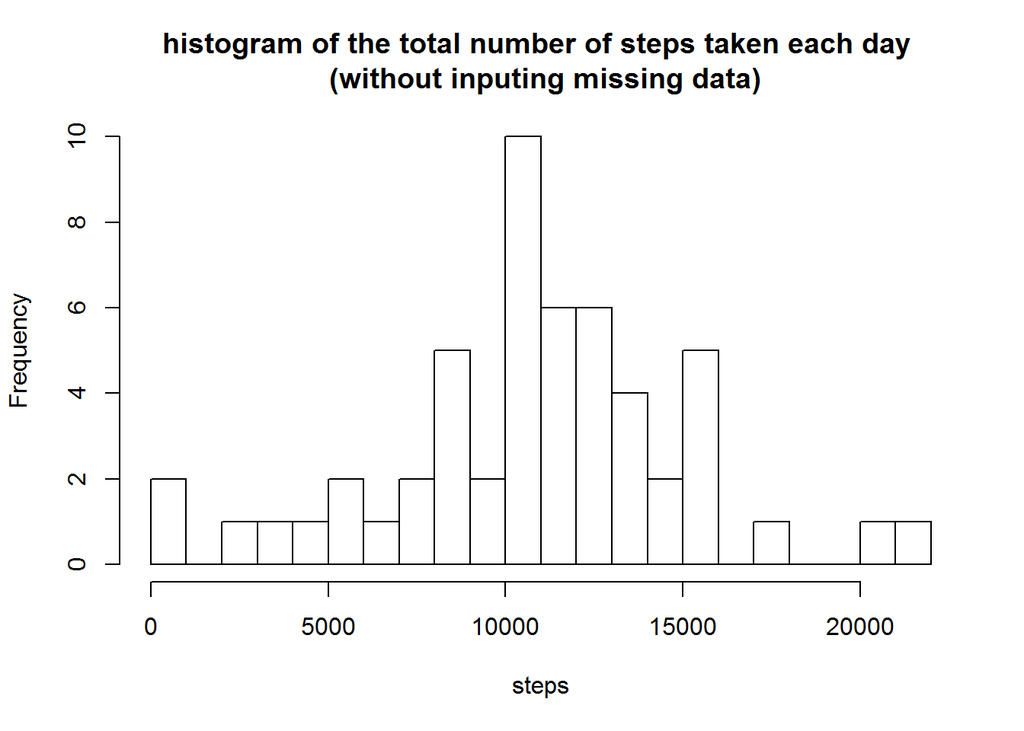

```r
hist(Agg_data$x,20,xlab = "steps",main = "histogram of the total number of steps taken each day \n (without inputing missing data)")
```

Calculate the mean and median of the total number of steps taken per day

```r
mean_step <- mean(Agg_data$x)
mean_step
```

```
## [1] 10766.19
```

```r
median_step <- median(Agg_data$x)
median_step
```

```
## [1] 10765
```

## Part 3

Make a time series plot (i.e. type = “l”) of the 5-minute interval (x-axis) and the average number of steps taken, averaged across all days (y-axis)

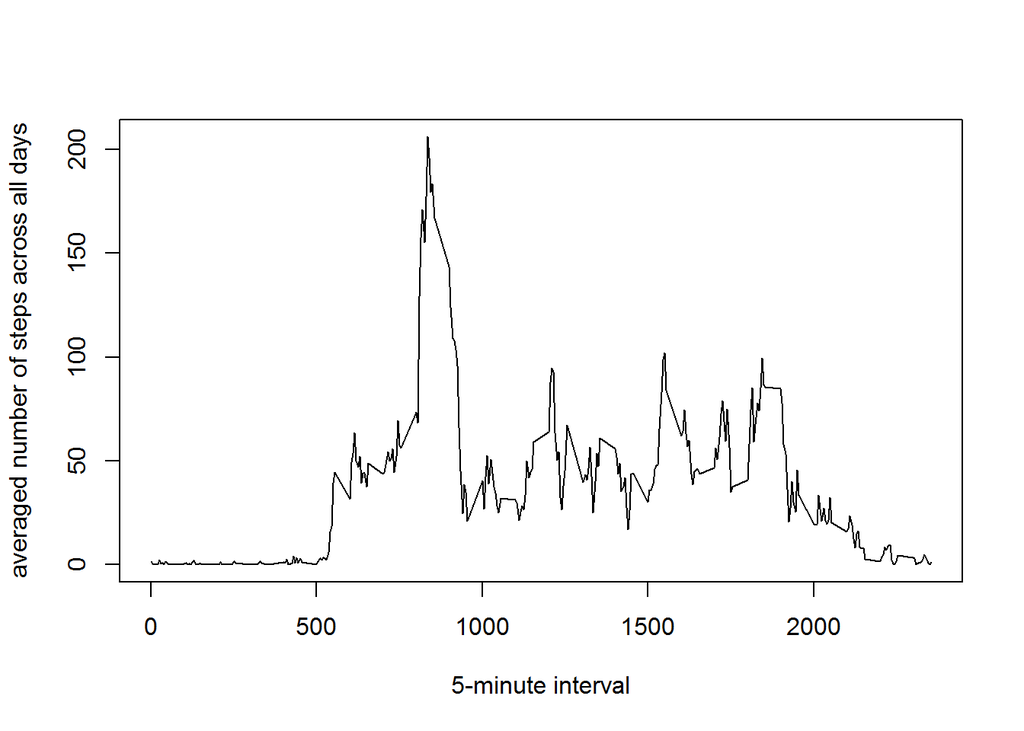

```r
DailyavgSteps <- aggregate(data$steps, by = list(interval = data$interval), FUN = "mean")
plot(DailyavgSteps$interval, DailyavgSteps$x,type ='l', ylab = "averaged number of steps across all days", xlab = "5-minute interval")
```

Find the 5-minute interval which contains the maximum number of steps, on average across all the days in the dataset.

```r
index=which(DailyavgSteps[,2]==max(DailyavgSteps[,2]))
DailyavgSteps[index,1]
```

```
## [1] 835
```

## Part 4

Calculate and report the total number of missing values in the dataset

```r
nrow(origin_data) - nrow(data)
```

```
## [1] 2304
```

Devise a strategy for filling in all of the missing values in the dataset. The strategy does not need to be sophisticated. Here I use the mean for that interval.

Create a new dataset that is equal to the original dataset but with the missing data filled in.

```r
newdata <- origin_data
for (i in 1:nrow(newdata)) {
  if (is.na(newdata$steps[i])) {
    newdata$steps[i] <- DailyavgSteps[which(newdata$interval[i] == DailyavgSteps$interval), ]$x
  }
}
str(newdata)
```

```
## 'data.frame':    17568 obs. of  3 variables:
##  $ steps   : num  1.717 0.3396 0.1321 0.1509 0.0755 ...
##  $ date    : Factor w/ 61 levels "2012-10-01","2012-10-02",..: 1 1 1 1 1 1 1 1 1 1 ...
##  $ interval: int  0 5 10 15 20 25 30 35 40 45 ...
```

Make a histogram of the total number of steps taken each day and Calculate and report the mean and median total number of steps taken per day. Do these values differ from the estimates from the first part of the assignment? What is the impact of imputing missing data on the estimates of the total daily number of steps?

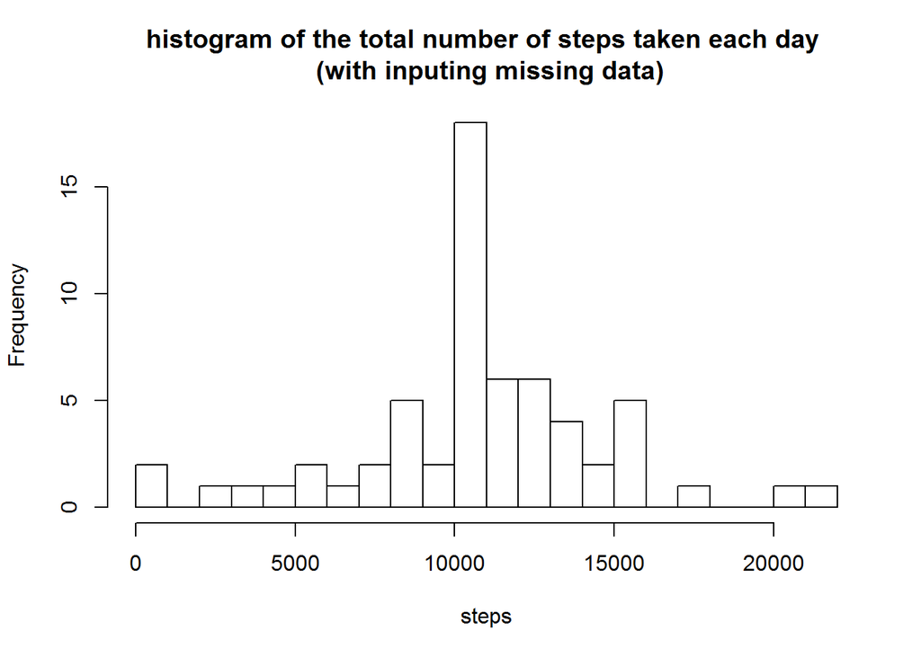

```r
Agg_newdata <- aggregate(newdata$steps, by = list(Date = newdata$date), FUN = "sum")
hist(Agg_newdata$x,20,xlab = "steps",main = "histogram of the total number of steps taken each day \n (with inputing missing data)")
```

```r
mean_step_newdata <- mean(Agg_newdata$x)
mean_step_newdata
```

```
## [1] 10766.19
```

```r
mean_step
```

```
## [1] 10766.19
```

```r
median_step_newdata <- median(Agg_newdata$x)
median_step_newdata
```

```
## [1] 10766.19
```

```r
median_step
```

```
## [1] 10765
```

From above, it can be seen that the mean total number of steps taken per day is the same as that from the previous part. The median totoal number of steps taken per day is differeent to that from the previous part.

By imputing missing data, the estimates of the total daily number of steps changes. Specifically, the median total number of steps is equivalent to the mean total number of steps.

## Part 5

Create a new factor variable in the dataset with two levels - “weekday” and “weekend” indicating whether a given date is a weekday or weekend day.

```r
mydate <- factor(newdata$date)
newdata$weekdays <- factor(weekdays(as.Date(mydate)))
levels(newdata$weekdays) = list('weekday' = 'Friday', 'weekday' = 'Monday', 'weekday' =  'Thursday', 'weekday' = 'Tuesday', 'weekday' = 'Wednesday', 'weekend' = 'Saturday','weekend' ='Sunday')
```

Make a panel plot containing a time series plot (i.e. type = “l”) of the 5-minute interval (x-axis) and the average number of steps taken, averaged across all weekday days or weekend days (y-axis).

```r
Agg_weekday <- aggregate(newdata$steps, by = list( interval = newData$interval,weekdays = newdata$weekdays), FUN = "mean")
require(lattice)
```

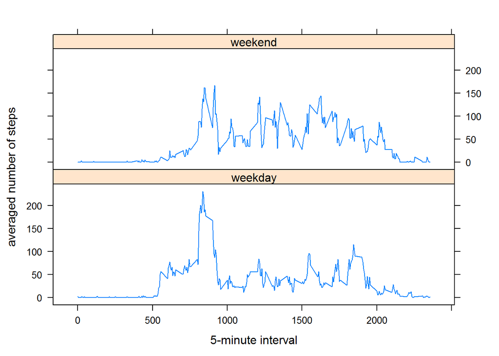

```r
xyplot(Agg_weekday$x~Agg_weekday$interval|Agg_weekday$weekdays, type = 'l', layout = c(1,2), xlab = "5-minute interval", ylab = "averaged number of steps")
```